# PSTAT131 Homework 2

Shivani Kharva

2022-10-03

# Homework 2

## Linear Regression

**Reading in the data and loading it in**

```r
abalone <- read.csv("abalone.csv")
library(tidyverse)
library(tidymodels)
```

### Question 1

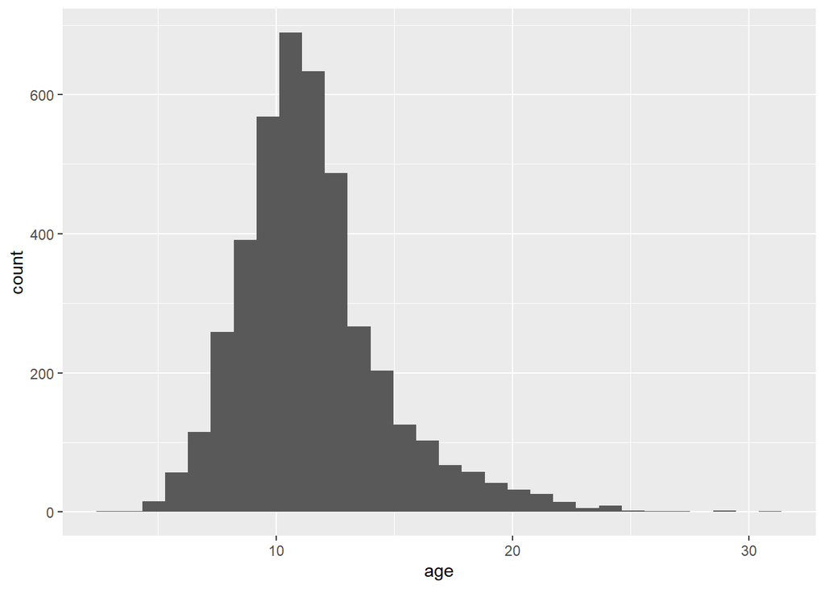

```r
# Adding age to dataset
abalone2 <- abalone %>%
  mutate(age = rings + 1.5)

# Assessing distribution of age
age_dist <- ggplot(abalone2, aes(age)) +
  geom_histogram()
age_dist
```

The distribution of `age` is right skewed and unimodal. There is a peak in the data at around 11 years old. Most of the data lies between ~8 and ~13 years of age.

### Question 2

```r
# Setting the seed
set.seed(0124)

# Splitting the data
abalone_split <- initial_split(abalone2, prop = 0.70, strata = age)
abalone_train <- training(abalone_split)
abalone_test <- testing(abalone_split)
```

### Question 3

We should not use `rings` to predict `age` because the `rings` variable would be able to give us the exact age by adding 1.5 to it. There would be no need to predict `age` if we could just directly calculate it using `rings` (also the purpose of the prediction is to be able to predict the age without cutting open the abalone to find out how many rings it has). So, we should not use `rings` to predict `age`.

```r
# Creating a recipe predicting the outcome variable, age

# Creating abalone training set without rings variable
abalone_train2 <- abalone_train[, !names(abalone_train) %in% c("rings")]

# Creating the recipe
abalone_recipe <- recipe(age ~ ., data = abalone_train2) %>%
  # Dummy coding any categorical predictors
  step_dummy(all_nominal_predictors())  %>%
  # Creating the interactions
  step_interact(terms = ~ starts_with("type"):shucked_weight + longest_shell:diameter + shucked_weight:shell_weight) %>%
  # Centering all predictors
  step_center(all_predictors()) %>%
  # Scaling all predictors
  step_scale(all_predictors())
```

### Question 4

```r
# Creating and storing a linear regression object using lm engine
lm_model <- linear_reg() %>%
  set_engine("lm")
```

### Question 5

```r
# Setting up an empty workflow
lm_workflow <- workflow() %>%
  # Adding the model
  add_model(lm_model) %>%
  # Adding the recipe
  add_recipe(abalone_recipe)
```

### Question 6

```r
# Fitting the model to the training set
lm_fit <- fit(lm_workflow, abalone_train2)

# Visualizing the result
lm_fit %>%
  extract_fit_parsnip() %>%
  tidy()
```

```
## # A tibble: 14 × 5
##    term                          estimate std.error statistic  p.value
##    <chr>                            <dbl>     <dbl>     <dbl>    <dbl>
##  1 (Intercept)                    11.4       0.0397  288.     0
##  2 longest_shell                   0.823     0.303     2.72   6.63e- 3
##  3 diameter                        1.90      0.328     5.80   7.27e- 9
##  4 height                          0.242     0.0710    3.40   6.82e- 4
##  5 whole_weight                    4.72      0.423    11.2    2.07e-28
##  6 shucked_weight                 -4.39      0.272   -16.1    3.75e-56
##  7 viscera_weight                 -0.857     0.170    -5.04   5.01e- 7
##  8 shell_weight                    1.74      0.227     7.68   2.21e-14
##  9 type_I                         -1.00      0.124    -8.12   7.00e-16
## 10 type_M                         -0.312     0.110    -2.84   4.54e- 3
## 11 type_I_x_shucked_weight         0.560     0.0931    6.02   1.98e- 9
## 12 type_M_x_shucked_weight         0.303     0.116     2.62   8.86e- 3
## 13 longest_shell_x_diameter       -2.93      0.430    -6.81   1.19e-11
## 14 shucked_weight_x_shell_weight   0.0167    0.218     0.0765 9.39e- 1
```

```r
# Predicting the age of the hypothetical female abalone
new_sample <- tibble(longest_shell = 0.50, diameter = 0.10, height = 0.30, whole_weight = 4, shucked_weight = 1, viscera_weight = 2, shell_weight = 1, type='F')

predict(lm_fit, new_data = new_sample)
```

```
## # A tibble: 1 × 1
##   .pred
##   <dbl>
## 1  25.4
```

The predicted age is 25.39588 years old.

### Question 7

```r
library(yardstick)

# Creating metric set
abalone_metrics <- metric_set(rmse, rsq, mae)
abalone_metrics
```

```
## # A tibble: 3 × 3
##   metric class          direction
##   <chr>  <chr>          <chr>
## 1 rmse   numeric_metric minimize
## 2 rsq    numeric_metric maximize
## 3 mae    numeric_metric minimize
```

```r
# Creating tibble of model's predicted values from the training data with actual observed ages
abalone_tibble <- predict(lm_fit, new_data = abalone_train2 %>% select(-age))
abalone_tibble <- bind_cols(abalone_tibble, abalone_train2 %>%
                              select(age))
head(abalone_tibble)
```

```
## # A tibble: 6 × 2
##   .pred   age
##   <dbl> <dbl>
## 1  8.07   8.5
## 2  9.77   8.5
## 3 10.0    9.5
## 4  6.28   6.5
## 5  7.70   7.5
## 6 10.2    8.5
```

```r
# Applying metric set to tibble
abalone_tibble_metrics <- abalone_metrics(abalone_tibble, truth = age, estimate = .pred)
abalone_tibble_metrics
```

```
## # A tibble: 3 × 3
##   .metric .estimator .estimate
##   <chr>   <chr>          <dbl>
## 1 rmse    standard       2.14
## 2 rsq     standard       0.560
## 3 mae     standard       1.55
```

**Results:**  
The RMSE is about 2.1423, the $R^2$ value is about 0.5599, and the MAE is about 1.5516. An $R^2$ value of 0.5599 means that about 55.99% of the variation in `age` is explained by the linear model. An $R^2$ value of 0.5599 is not very high, so I would say that this model is not a very good model for predicting the age of abalone.